# Lecture 9: Relationships Between Variables, Part 1

Nick Huntington-Klein

February 5, 2019

## Recap

- Summary statistics are ways of describing the *distribution* of a variable
- We can also just look at the variable directly
- Understanding a variable’s distribution is important if we want to use it

## This week

- We aren’t just interested in looking at variables by themselves!
- We want to know how variables can be *related* to each other
- When `X` is high, would we expect `Y` to also be high, or be low?
- How are variables *correlated*?
- How does one variable *explain* another?
- How does one variable *cause* another? (later!)

## What Does it Mean to be Related?

- We would consider two variables to be *related* if knowing something about *one* of them tells you something about the other
- For example, consider the answer to two questions:
  - Are you a man?
  - Are you pregnant?
- What do you think is the probability that a random person is pregnant?
- What do you think is the probability that a random person *who is a man* is pregnant?

## What does it Mean to be Related?

Some terms:

- Variables are *dependent* on each other if telling you the value of one gives you information about the distribution of the other
- Variables are *correlated* if knowing whether one of them is *unusually high* gives you information about whether the other is *unusually high* (positive correlation) or *unusually low* (negative correlation)
- *Explaining* one variable `Y` with another `X` means predicting *your `Y`* by looking at the distribution of `Y` for *your* value of `X`
- Let’s look at two variables as an example

## An Example: Dependence

```r
table(wage1$numdep,wage1$smsa,dnn=c('Num. Dependents','Lives in Metropolitan Area'))
```

```
##                Lives in Metropolitan Area
## Num. Dependents   0   1
##               0  60 192
##               1  27  78
##               2  38  61
##               3  13  32
##               4   3  13
##               5   3   4
##               6   2   0
```

## An Example: Dependence

- What are we looking for here?
- For *dependence*, simply see if the distribution of one variable changes for the different values of the other.
- Does the distribution of Number of Dependents differ based on your SMSA status?

```r
prop.table(table(wage1$numdep,wage1$smsa,dnn=c('Num. Dependents','Lives in Metropolitan Area')),margin=2)
```

```
##                Lives in Metropolitan Area
## Num. Dependents          0          1
##               0 0.41095890 0.50526316
##               1 0.18493151 0.20526316
##               2 0.26027397 0.16052632
##               3 0.08904110 0.08421053
##               4 0.02054795 0.03421053
##               5 0.02054795 0.01052632
##               6 0.01369863 0.00000000
```

## An Example: Dependence

- Does the distribution of SMSA differ based on your Number of Dependents Status?

```r
prop.table(table(wage1$numdep,wage1$smsa,dnn=c('Number of Dependents','Lives in Metropolitan Area')),margin=1)
```

```
##                     Lives in Metropolitan Area
## Number of Dependents         0         1
##                    0 0.2380952 0.7619048
##                    1 0.2571429 0.7428571
##                    2 0.3838384 0.6161616
##                    3 0.2888889 0.7111111
##                    4 0.1875000 0.8125000
##                    5 0.4285714 0.5714286
##                    6 1.0000000 0.0000000
```

- Looks like it!
- What do these two results mean?

## An Example: Correlation

- We are interested in whether two variables tend to *move together* (positive correlation) or *move apart* (negative correlation)
- One basic way to do this is to see whether values tend to be *high* together
- One way to check in dplyr is to use `group_by()` to organize the data into groups
- Then `summarize()` the data within those groups

```r
wage1 %>%
  group_by(smsa) %>%
  summarize(numdep=mean(numdep))
```

```
## # A tibble: 2 x 2
##    smsa numdep
##   <dbl>  <dbl>
## 1     0  1.24
## 2     1  0.968
```

- When `smsa` is high, `numdep` tends to be low - negative correlation!

## An Example: Correlation

- There’s also a summary statistic we can calculate *called* correlation, this is typically what we mean by “correlation”
- Ranges from -1 (perfect negative correlation) to 1 (perfect positive correlation)
- Basically “a one-standard deviation increase in `X` is associated with a correlation-standard-deviation increase in `Y`”

```r
cor(wage1$numdep,wage1$smsa)
```

```
## [1] -0.09636769
```

```r
cor(wage1$smsa,wage1$numdep)
```

```
## [1] -0.09636769
```

## An Example: Explanation

Let’s go back to those different means:

```
## # A tibble: 2 x 2
##    smsa numdep
##   <dbl>  <dbl>
## 1     0  1.24
## 2     1  0.968
```

- Explanation would be saying that, based on this, if you’re in an SMSA, I predict that you have 0.9684211 dependents, and if you’re not, you have 1.239726 dependents
- If you are in an SMSA and have 2 dependents, then 0.9684211 of those dependents are *explained by SMSA* and 2 - 0.9684211 = 1.0315789 of them are *unexplained by SMSA*
- We’ll talk a lot more about this later

## Coding Recap

- `table(df$var1,df$var2)` to look at two variables together
- `prop.table(table(df$var1,df$var2))` for the proportion in each cell
- `prop.table(table(df$var1,df$var2),margin=2)` to get proportions *within each column*
- `prop.table(table(df$var1,df$var2),margin=1)` to get proportions *within each row*
- `df %>% group_by(var1) %>% summarize(mean(var2))` to get mean of var2 for each value of var1
- `cor(df$var1,df$var2)` to calculate correlation

## Graphing Relationships

- Relationships between variables can be easier to see graphically
- And graphs are extremely important to understanding relationships and the “shape” of those relationships

## Wage and Education

- Let’s use `plot(xvar,yvar)` with *two* variables

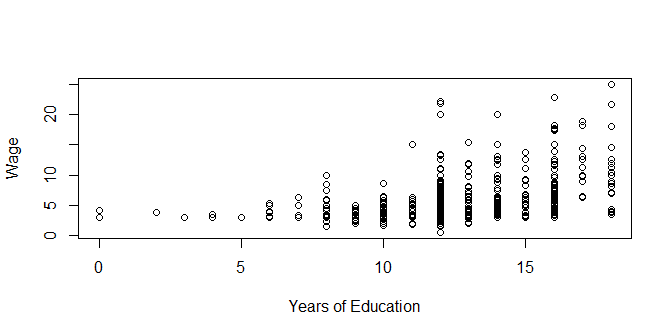

```r
plot(wage1$educ,wage1$wage,xlab="Years of Education",ylab="Wage")
```

- As we look at different values of `educ`, what changes about the values of `wage` we see?

## Graphing Relationships

- Try to picture the *shape* of the data
- Should this be a straight line? A curved line? Positively sloped? Negatively?

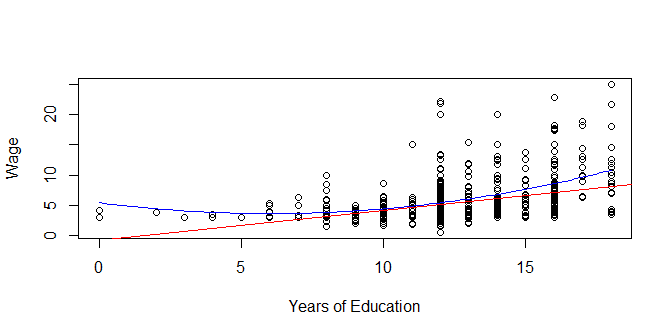

```r
plot(wage1$educ,wage1$wage,xlab="Years of Education",ylab="Wage")
abline(-.9,.5,col='red')
plot(function(x) 5.4-.6*x+.05*(x^2),0,18,add=TRUE,col='blue')
```

## Graphing Relationships

- `plot(xvar,yvar)` is extremely powerful, and will show you relationships at a glance
- The previous graph showed a clear positive relationship, and indeed `cor(wage1$wage,wage1$educ)` = 0.4059033
- Further, we don’t only see a positive relationship, but we have some sense of *how* positive it is, what it looks like roughly
- Let’s look at some more

## Graphing Relationships

- Let’s compare clothing sales volume vs. profit margin for men’s clothing firms

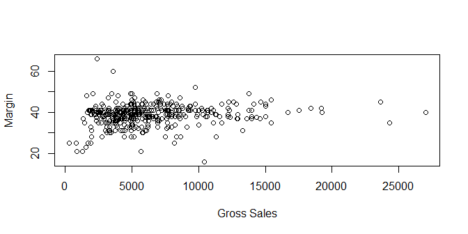

```r
library(Ecdat)
data(Clothing)
plot(Clothing$sales,Clothing$margin,xlab="Gross Sales",ylab="Margin")
```

- No clear up-or-down relationship (although the correlation is 0.1373499!) but clearly the variance is higher for low sales

## Graphing Relationships

- Comparing Singapore diamond prices vs. carats

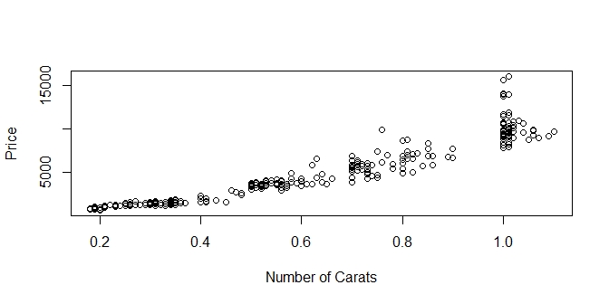

```r
library(Ecdat)
data(Diamond)
plot(Diamond$carat,Diamond$price,xlab="Number of Carats",ylab="Price")
```

## Graphing Relationships

- Another way to graph a relationship, especially when one of the variables only takes a few values, is to plot the `density()` function for different values

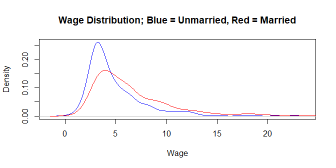

- Clearly different distributions: married people earn more!

## Graphing relationships

- We can back that up other ways

```r
wage1 %>% group_by(married) %>% summarize(wage = mean(wage))
```

```
## # A tibble: 2 x 2
##   married  wage
##     <dbl> <dbl>
## 1       0  4.84
## 2       1  6.57
```

```r
cor(wage1$wage,wage1$married)
```

```
## [1] 0.2288172
```

## Keep in mind!

- Just because two variables are *related* doesn’t mean we know *why*
- If `cor(x,y)` is positive, it could be that `x` causes `y`… or that `y` causes `x`, or that something else causes both!
- Or many other configurations… we’ll talk about this after the midterm
- Plus, even if we know the direction we may not know *why* that cause exists.

## For example

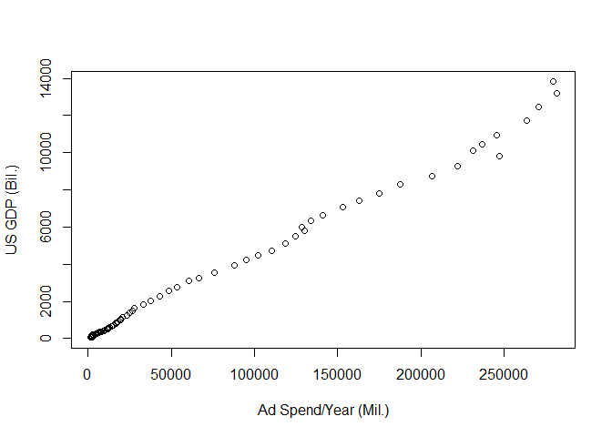

```r
addata <- read.csv('http://www.nickchk.com/ad_spend_and_gdp.csv')
plot(addata$AdSpending,addata$GDP,
     xlab='Ad Spend/Year (Mil.)',ylab='US GDP (Bil.)')
```

## For example

- The correlation between ad spend and GDP is 0.9974593
- Does this mean that ads make GDP go up?
- To some extent, yes (ad spending factors directly into GDP)
- But that doesn’t explain all of it!
- Why else might this relationship exist?

## Practice

- Install the `SMCRM` package, load it, get the `customerAcquisition` data. Rename it ca
- Among `acquisition==1` observations, see if the size of first purchase is related to duration as a customer, with `cor` and (labeled) `plot`
- See if `industry` and `acquisition` are dependent on each other using `prop.table` with the `margin` option
- See if average revenues differ between industries using `aggregate`, then check the `cor`
- Plot the density of revenues for `industry==0` in blue and, on the same graph, revenues for `industry==1` in red
- In each case, think about relationship is suggested

## Practice Answers

```r
install.packages('SMCRM')
library(SMCRM)
data(customerAcquisition)
ca <- customerAcquisition
cor(filter(ca,acquisition==1)$first_purchase,filter(ca,acquisition==1)$duration)
plot(filter(ca,acquisition==1)$first_purchase,filter(ca,acquisition==1)$duration,
     xlab="Value of First Purchase",ylab="Customer Duration")
prop.table(table(ca$industry,ca$acquisition),margin=1)
prop.table(table(ca$industry,ca$acquisition),margin=2)
aggregate(revenue~industry,data=ca,FUN=mean)
cor(ca$revenue,ca$industry)
plot(density(filter(ca,industry==0)$revenue),col='blue',xlab="Revenues",main="Revenue Distribution")
lines(density(filter(ca,industry==1)$revenue),col='red')
```